# Platypus vignette

Alexander Yermanos

2021-04-19

## 1. Introduction

Platypus is a package designed to facilitate the analysis of single-cell immune repertoire sequencing experiments. The package can be used to separately analyze gene expression (GEX) or immune receptor repertoire (VDJ) sequencing data, in addition to integrating the two data sets to combine phenotypic features with repertoire analysis. The package is designed to primarily analyze the output from 10x genomics cellranger (output from count for GEX and VDJ for enriched immune receptor libraries). The functions could work with other barcode-based scSeq technologies assuming the input columns are added correctly. The gene expression analysis relies heavily upon Seurat, a commonly used R package for single-cell sequencing (scSeq). The core software can be found at https://github.com/alexyermanos/Platypus and examples of use can be found in the publication https://doi.org/10.1093/nargab/lqab023

Current functions in development can be found at the functions branch of the github https://github.com/alexyermanos/Platypus/tree/Functions/R

## 2. Installation (Platypus v3)

Due to the recent changes of the default clonotyping strategy in Cellranger (version 5 and version 6) we are currently rebuilding v3 of Platypus to revolve around the VDJ_GEX_matrix function (vgm for short). This function integrates both repertoire and transcriptome information and will serve as the input to all secondary functions in future iterations of the package. The advantage of this is having all repertoire and transcriptome information at a per-cell level.

The change in clonotyping can be found here - https://support.10xgenomics.com/single-cell-vdj/software/pipelines/latest/algorithms/clonotyping

The VDJ_GEX_matrix function will soon be found in the newest version of the R package (v3.0) with special thanks to Victor Kreiner. The current functions and documentation can be found already at https://github.com/alexyermanos/Platypus/blob/Functions/R/VDJ_GEX_matrix.R

Can stay tuned for updates https://twitter.com/AlexYermanos

```r
### Removing any previous versions of the package
#First can ensure that there is no previous version installed locally
#detach("package:Platypus", unload=TRUE)
#remove.packages("Platypus")

### Dependencies
#install.packages("stringr")


### Downloading and installing Platypus

# First we need to download the most recent version from the master branch at https://github.com/alexyermanos/Platypus we can install the package using the following command.
# WARNING: This needs to be replaced with your own directory where the downloaded package is found

# For MacOS users it may look like this
#install.packages("~/Downloads/Platypus_3.0.tar.gz", repos = NULL, type="source")

# For windows it will likely look something like this.
# WARNING: You will need to replace 'YourPCName' with your user name for the windows account in the directory.
# install.packages("C:\Users\YourPCName\Downloads\Platypus_3.0.tar.gz", repos = NULL, type="source")

# Now we can load the installed package into the R environment. In case of problems with installing other R packages that are used in Platypus, please see the README file at the https://github.com/alexyermanos/Platypus, where we outline how to install the other R packages for both Windows and MacOS.
#library(Platypus)

# The individual R functions can additionally be found on the github in the Functions branch. Within this branch, there is a folder "R" which contains the individual functions. This can similarly be downloaded and loaded into the R environment in case not all functions are desired. These functions are actively updated and may include more features than the in original tar.gz file.
```

## 3. Extracting and integrating repertoire data with VDJ_GEX_matrix (Platypus v3)

```r
### Downloading the test data for VDJ_GEX_matrix
# While the Platypus manuscript uses the COVID-19 data, the vignette for Platypus v3 will use the data from B cells in the aged CNS, which can be found at the following link https://polybox.ethz.ch/index.php/s/fxQJ3NrRSwiPSSo This small dataset contains VDJ (separate libraries for B) and GEX libraries from the central nervous system of two murine samples. More information can be found https://doi.org/10.1098/rspb.2020.2793

# After downloading the zip file named "Platypus_CNS_data.zip", please unzip the file and find the path to the newly formed folder. Typically this will be in the Downloads folder, so the code below should work on MacOS. For windows please uncomment the code and change the user name to match your PC.

VDJ.out.directory.list <- list() ### Set directory to the outs folder of cellranger vdj
VDJ.out.directory.list[[1]] <- c("~/Downloads/Platypus_CNS_data/VDJ_S1/")
VDJ.out.directory.list[[2]] <- c("~/Downloads/Platypus_CNS_data/VDJ_S2/")

GEX.out.directory.list <- list() ### Set directory to the outs folder of cellranger count
GEX.out.directory.list[[1]] <- c("~/Downloads/Platypus_CNS_data/GEX_S1/")
GEX.out.directory.list[[2]] <- c("~/Downloads/Platypus_CNS_data/GEX_S2/")

# For windows:
#directory_to_covid_patients_gex[[1]] <- c("C:\Users\YourPCName\Downloads\PlatypusTestData\Patient1_GEX")
#directory_to_covid_patients_gex[[2]] <- c("C:\Users\YourPCName\Downloads\PlatypusTestData\Patient2_GEX")

# We will call the output vgm (short for Vdj_Gex_Matrix) - this object can be supplied as input to downstream functions in v3 of the package.
vgm <- Platypus::VDJ_GEX_matrix(VDJ.out.directory.list = VDJ.out.directory.list,
                               GEX.out.directory.list = GEX.out.directory.list,
                               GEX.integrate = T,
                               VDJ.combine = T,
                               integrate.GEX.to.VDJ = T,
                               integrate.VDJ.to.GEX = T,
                               exclude.GEX.not.in.VDJ = F,
                               filter.overlapping.barcodes.GEX = F,
                               filter.overlapping.barcodes.VDJ = F,
                               get.VDJ.stats = T,
                               parallel.processing = "none",
                               subsample.barcodes = F,
                               trim.and.align = F,
                               group.id = c(1,2))
## The output will be a list -
# vgm[[1]] corresponds to the VDJ master dataframe
# vgm[[2]] corresponds to the GEX in the form of a seurat object
# vgm[[3]] corresponds to the output of VDJ_stats subfunction - which provides information about the number of chains, sequencing reads, etc
# vgm[[4]] holds the input parameters
# vgm[[5]] holds the sessionInfo output at the time of function call
```

```r
head(colnames(vgm[[1]]))
```

```
## [1] "barcode"          "sample_id"        "group_id"         "clonotype_id_10x"
## [5] "celltype"         "Nr_of_VDJ_chains"
```

```r
## By setting integrate.GEX.to.VDJ and integrate.VDJ.to.GEX to T, VDJ and GEX information will be found in vgm[[1]] and vgm[[2]] objects.
# For example, the seurat-determined cluster is attached to each cell in the VDJ library by
head(vgm[[1]]$seurat_clusters)
```

```
## [1] <NA> 5    0    0    0    0
## Levels: 0 1 2 3 4 5 6 7
```

```r
# which corresponds to cells with the following VDJ_cdr3
head(vgm[[1]]$VDJ_cdr3s_aa)
```

```
## [1] "CARIGYAMDYW"        "CARDFTTVVARGYFDVW"  "CARGITTVVAYYYAMDYW"
## [4] "CTTGPYDYYAMDYW"     "CARPHDYDGVDYW"      "CARRYYSNYAWFAYW"
```

```r
# an NA indicates that the cell barcode in the VDJ library was not detected in the GEX object (or was filtered out, depending on mitochondrial gene limits, etc)

## Setting trim.and.align to TRUE will dramatically increase the run time but will also provide full-length VDJ and VJ sequences.

# In Platypus version 2, the output from GEX_automate was used as input to other GEX functions. These functions are still compatible with v3 if the vgm[[2]] seurat object is supplied as input.
# For example, the following function can be used to calculate the DE genes for each cluster, as before.
genes_per_cluster <- Platypus::GEX_cluster_genes(vgm[[2]])
head(genes_per_cluster[[1]]) ## Can see the top DE genes for cluster 0.
```

```
##                p_val avg_logFC pct.1 pct.2    p_val_adj  SYMBOL cluster
## FCMR    3.734083e-63  2.370659 0.809 0.068 1.182995e-58    FCMR       0
## H2-DMB2 1.841030e-61  2.304210 0.831 0.090 5.832568e-57 H2-DMB2       0
## CD74    1.533833e-55  2.489139 1.000 0.345 4.859338e-51    CD74       0
## CD79A   4.761892e-54  2.125782 1.000 0.289 1.508615e-49   CD79A       0
## H2-EB1  3.592103e-53  2.191929 0.904 0.169 1.138014e-48  H2-EB1       0
## H2-AB1  1.158780e-52  2.278966 0.904 0.191 3.671131e-48  H2-AB1       0
```

```r
## This function can similarly be used when only VDJ or GEX data is present. Simply leave the list
# VDJ_comb_gex <- VDJ_GEX_matrix(VDJ.out.directory.list = VDJ.out.directory.list,
#                                #GEX.out.directory.list = GEX.out.directory.list,
#                                GEX.integrate = F,
#                                VDJ.combine = T,
#                                integrate.GEX.to.VDJ = F,
#                                integrate.VDJ.to.GEX = F,
#                                exclude.GEX.not.in.VDJ = F,
#                                filter.overlapping.barcodes.GEX = F,
#                                filter.overlapping.barcodes.VDJ = F,
#                                get.VDJ.stats = F,
#                                parallel.processing = "none",
#                                subsample.barcodes = F,
#                                trim.and.align = F,
#                                group.id = c(1,2))
```

## 4. Gene expression analysis (Platypus v2)

The output from cellranger’s count function returns gene expression information in the form of an expression matrix, barcodes, and gene identifiers. The function automate_GEX allows us to automate the transcriptional analysis of the gene expression libraries from cellranger. The input directory should be set to the directory containing these three files: barcodes.tsv.gz, features.tsv.gz, matrix.mtx.gz. If it is desired to analyze multiple distinct transcriptomes (e.g., on separate UMAP space), these directories should go into separate list objects. For example, if there are 20 repertoires and it is wanted to analyze them separately (20 separate UMAPs, 20 separate repertoires) then each outer list element of the input directories will contain the directory for the individual repertoire/GEX files. The output of this function is a Seurat object similar to the standard pipeline demonstrated in the Seurat vignette. This involves scaling, normalizing, clustering, and performing dimensionality reduction (tSNE and UMAP by default). At this stage, there is no incorporation of repertoire features, which need to be explicitly integrated using subsequent functions in Platypus.

In the example below two directories are supplied to two distinct list elements, and thus these distinct transcriptomes (corresponding to two distinct repertoires) will each be associated to a distinct Seurat object.

```r
### Removing any previous versions of the package
#First, ensure there is no previous version installed locally
#detach("package:Platypus", unload=TRUE)
#remove.packages("Platypus")

### Downloading and installing Platypus

# Download most recent version from master branch at https://github.com/alexyermanos/Platypus We can install the package using the following command.
# WARNING: This needs to be replaced with your own directory where the downloaded package is found

# For MacOS users it may look like this:
#install.packages("~/Downloads/Platypus_2.0.5.tar.gz", repos = NULL, type="source")

# For windows it will likely look something like this:
# WARNING: You will need to replace 'YourPCName' with your user name for the windows account in the directory.
# install.packages("C:\Users\YourPCName\Downloads\Platypus_2.0.6.tar.gz", repos = NULL, type="source")

# Now we can load the installed package into the R environment. In case of problems with installing other R packages that are used in Platypus, please see the README file at the https://github.com/alexyermanos/Platypus, where we outline how to install the other R packages for both Windows and MacOS.
library(Platypus)

# Individual R functions can additionally be found on the github Functions branch. Within this branch, there is a folder "R" which contains the individual functions. This can similarly be downloaded and loaded into the R environment in case not all functions are desired. These functions are actively updated and may include more features than the in original tar.gz file.


### Downloading the test data
# The COVID-19 data (~136 MB size of the zip file) can be found at the following link https://polybox.ethz.ch/index.php/s/fxQJ3NrRSwiPSSo This dataset contains VDJ (separate libraries for B and T cells) and GEX libraries from two convalescent COVID-19 patients.

# After downloading the zip file named "PlatypusTestData.zip", please unzip the file and find the path to the newly formed folder. Typically this will be in the Downloads folder, so the code below should work on MacOS. For Windows please uncomment the code and change the user name to match your PC.

directory_to_covid_patients_gex <- list()
directory_to_covid_patients_gex[[1]] <- c("~/Downloads/PlatypusTestData/Patient1_GEX/")
directory_to_covid_patients_gex[[2]] <- c("~/Downloads/PlatypusTestData/Patient2_GEX/")

# For Windows:
#directory_to_covid_patients_gex[[1]] <- c("C:\Users\YourPCName\Downloads\PlatypusTestData\Patient1_GEX")
#directory_to_covid_patients_gex[[2]] <- c("C:\Users\YourPCName\Downloads\PlatypusTestData\Patient2_GEX")
```

GEX_automate allows us to perform the standard Seurat pipeline in a single line of code with the ability to change the parameters used by Seurat involving minimum read numbers, mitochondrial gene percentages, cluster resolution, etc. In addition, we can remove antibody and TCR genes from the data set (e.g. IGHV1-1) to not let clonality impact transcriptional clustering by simply setting the VDJ.gene.filter argument to TRUE.

```r
covid_gex_patients_not_integrated <- Platypus::GEX_automate(GEX.outs.directory.list = directory_to_covid_patients_gex,integration.method = "scale.data",mito.filter = 20,cluster.resolution = 0.5,VDJ.gene.filter = T)
```

```
## [1] "This may take longer than other repertoire associated functions. Please see Seurat vingenettes for further information"
## Modularity Optimizer version 1.3.0 by Ludo Waltman and Nees Jan van Eck
##
## Number of nodes: 6871
## Number of edges: 227794
##
## Running Louvain algorithm...
## Maximum modularity in 10 random starts: 0.8910
## Number of communities: 13
## Elapsed time: 0 seconds
## Modularity Optimizer version 1.3.0 by Ludo Waltman and Nees Jan van Eck
##
## Number of nodes: 6055
## Number of edges: 206042
##
## Running Louvain algorithm...
## Maximum modularity in 10 random starts: 0.8826
## Number of communities: 12
## Elapsed time: 0 seconds
```

Based on the input given (2 directories as separate list objects), we get 2 distinct Seurat objects.

```r
length(covid_gex_patients_not_integrated) ## length of two
```

```
## [1] 2
```

```r
class(covid_gex_patients_not_integrated) ## output is a list
```

```
## [1] "list"
```

```r
class(covid_gex_patients_not_integrated[[1]]) ## Seurat object
```

```
## [1] "Seurat"
## attr(,"package")
## [1] "SeuratObject"
```

```r
ncol(covid_gex_patients_not_integrated[[1]]) ## 6871 cells
```

```
## [1] 6871
```

```r
ncol(covid_gex_patients_not_integrated[[2]]) ## 6055 cells
```

```
## [1] 6055
```

Now we can visualize the 2D plots for each patient individually. By default, UMAP, PCA, and TSNE reductions are included in the object. Under default parameters this will display all cells in the GEX library from Patient1. By changing to the second list element we can view the cells from Patient2.

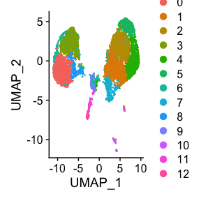

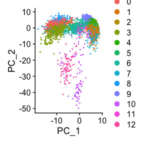

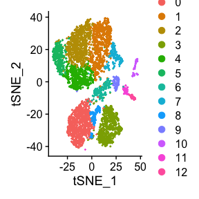

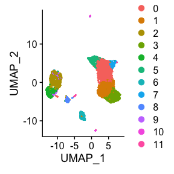

```r
Seurat::DimPlot(covid_gex_patients_not_integrated[[1]],reduction = "umap")

Seurat::DimPlot(covid_gex_patients_not_integrated[[1]],reduction = "pca")

Seurat::DimPlot(covid_gex_patients_not_integrated[[1]],reduction = "tsne")

# UMAP for the second patient
Seurat::DimPlot(covid_gex_patients_not_integrated[[2]],reduction = "umap")
```

If we are intrested in merging the transcripotmes (corresponding to two distinct gene expression libraries), then the two directories are supplied to a single list element. The output from GEX_automate (corresponding to a single Seurat object list element this time) contains a column with the sample origin information based on the order of the input directories. Additionally, one can label different samples by group in the case that biological replicates are present. In this case we simply set patients to group1 and group2

```r
directory_to_covid_patients_integrated <- list()
directory_to_covid_patients_integrated[[1]] <- c("~/Downloads/PlatypusTestData/Patient1_GEX/",
                                                 "~/Downloads/PlatypusTestData/Patient2_GEX/")

## Here we use the previous version of automate_GEX to produce the identical UMAP seen in the manuscript.
covid_gex <- Platypus::automate_GEX(GEX.outs.directory.list = directory_to_covid_patients_integrated[1:1],integration.method = "scale.data",mito.filter = 20,cluster.resolution = 0.5,VDJ.gene.filter = T)
```

```
## [1] "This may take longer than other repertoire associated functions. Please see Seurat vignettes for further information"
```

```
## Modularity Optimizer version 1.3.0 by Ludo Waltman and Nees Jan van Eck
##
## Number of nodes: 12926
## Number of edges: 426347
##
## Running Louvain algorithm...
## Maximum modularity in 10 random starts: 0.8928
## Number of communities: 13
## Elapsed time: 4 seconds
```

```r
### In this case, patient1 is the covid_gex[[1]]$sample_id==1 and patient2 is the covid_gex[[1]]$sample_id==2.

class(covid_gex) ## list
```

```
## [1] "list"
```

```r
length(covid_gex) ### list of length one
```

```
## [1] 1
```

```r
class(covid_gex[[1]]) ## Seurat object containing GEX from both samples
```

```
## [1] "Seurat"
## attr(,"package")
## [1] "SeuratObject"
```

We can extract which cells come from which sample based on the sample_id in the Seurat object.

```r
print(table(covid_gex[[1]]$sample_id))
```

```
##
##    1    2
## 6871 6055
```

We can see that the first patient had 6871 cells and the second patient had 6055 cells found in their gene expression data based on the current filtering.

Now we can visualize the samples using a UMAP/tsne plot.

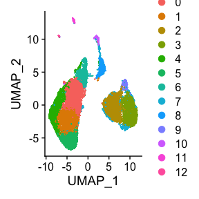

```r
Seurat::DimPlot(covid_gex[[1]],reduction = "umap")
```

In this current UMAP we do not see which cells are coming from which patient. To see this, we can simply separate the cells in the DimPlot by the sample_id vector in the Seurat object.

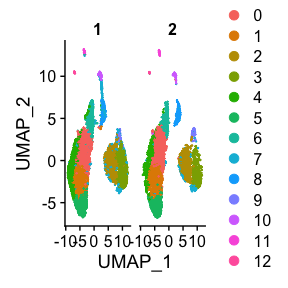

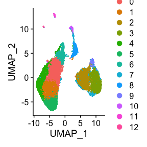

```r
Seurat::DimPlot(covid_gex[[1]],reduction = "umap",split.by = "sample_id")

Seurat::DimPlot(covid_gex[[1]],reduction = "umap")
```

```r
#Platypus::GEX_cluster_membership(automate_GEX.output = covid_gex[[1]])
```

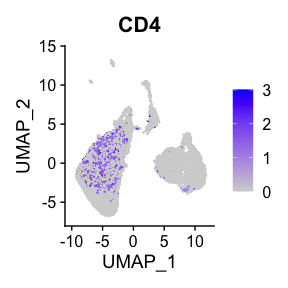

```r
#Seurat::FeaturePlot(covid_gex[[1]],reduction = "umap",features = c("CD4","CD8A","CD19"))
Seurat::FeaturePlot(covid_gex[[1]],reduction = "umap",features = c("CD4"))
```

```r
covid_gex_phenotype <- Platypus::GEX_phenotype(covid_gex[[1]], default = T)

covid_gex[[1]] <- Platypus::GEX_phenotype(covid_gex[[1]], default = F,
                                            cell.state.markers=c("CD8A+;CCL5+;CD44+;IL7R-;CD19-",
                          "CD8A+;CCL5-;CD44+;IL7R+;CD19-"),
                        cell.state.names=c("EffectorCD8",
                        "MemoryCD8"))
```

The resulting Seurat object now contains a “cell.state” column which can be used for annotation in the DimPlot function of the Seurat package.

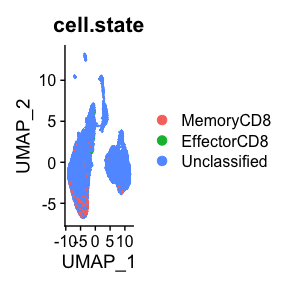

```r
Seurat::DimPlot(covid_gex[[1]],reduction = "umap", group.by = "cell.state")
```